# 2-sqrt-flowchart

$3^8$ = ?

위에 문제는 이해하기 쉽습니다.

'3을 8번 곱한다'가 이해해야할 전부입니다.

답은 컴퓨터가 구해줍니다.

이해하기 쉬운 프로그램은

답이 쉬운 프로그램이 아니라

문제를 파악하기 쉬운 프로그램입니다.

'제곱근 구하기'는 근삿값을 구하는 과정입니다.

여기서 필요한 건 2가지 뿐입니다.

1. 추측한 값이 충분히 참 값에 가까운지
2. 그렇지 않다면 필요한 과정을(연산을) 거치도록 하기

요약해서,

1. enough?
2. improve

라고 부르겠습니다.

계산과정이 명확하게 드러나도록 신호-흐름도를 작성해보면,

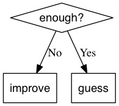

```python
from IPython.display import Image
Image(filename='img/sqrt-flowchart.jpg')
```

충분하다면 추측값이(guess) 답이고

아니면 improve 과정을 거치도록 합니다.

enough?와 improve에 해당하는 내용을 넣어 제곱근 함수를 다시 만들면,

```python
ALLOWABLE_ERROR = 0.001

def sqrt_iter(guess, x):
    def is_good_enough():
        return abs(guess**2 - x) < ALLOWABLE_ERROR

    def improve():
        return (guess + x/guess)/2

    if is_good_enough():
        return guess
    else:
        return sqrt_iter(improve(), x)
```

```python
sqrt_iter(1.0, 2)
```

```
1.4142156862745097
```

파이썬 표준 라이브러리인 `sqrt`로 대조해보면,

```python
import math
abs(sqrt_iter(1.0, 2) - math.sqrt(2))
```

```
2.123901414519125e-06
```

소수점 5째 자리까지 값이 일치함을 알 수 있습니다.

다음 글에서는 '복잡해보이는 문제를 간소화'하는 연습을 해보겠습니다.